# ECO-MRIO-SFC Model: 54-Sector Version Documentation

## $A$ Matrix

Importantly, the column names of the $A$ matrix contained in `identif` determine the country and industry labels in the whole model, following the grammar `country_label.industry_label`:

```r
kable(initial$A.matrix, booktabs = TRUE, digits = 4)
```

|  | EU.Agriculture | EU.Animal.Farming | EU.Forestry,.logging.and.related.service.activities.(02) | EU.Fishing,.operating.of.fish.hatcheries.and.fish.farms;.service.activities.incidental.to.fishing.(05) | EU.Extraction.of.Fossil-Fuels | EU.Mining.&.Quarrying.of.raw.materials | EU.Processing.of.meat | EU.Processing.of.other.food&beverage | EU.Manufacture.of.tobacco.products.(16) | EU.Manufacture.of.textiles | EU.Manufacture.of.wood.and.of.products.of.wood.and.cork,.except.furniture;.manufacture.of.articles.of.straw.and.plaiting.materials.(20) | EU.Re-processing.of.secondary.wood.material.into.new.wood.material | EU.Pulp | EU.Re-processing.of.secondary.paper.into.new.pulp | EU.Paper | EU.Processing.of.Fossil.Fuels | EU.Plastics,.basic | EU.Re-processing.of.secondary.plastic.into.new.plastic | EU.Manufacture.of.Chemicals | EU.Manufacture.of.rubber.and.plastic.products.(25) | EU.Manufacture.of.glass.and.glass.products | EU.Re-processing.of.secondary.glass.into.new.glass | EU.Manufacture.of.other.non-metallic.mineral.products | EU.Manufacture.of.cement,.lime.and.plaster | EU.Re-processing.of.ash.into.clinker | EU.Manufacture.of.Metals | EU.Re-processing.of.Metals | EU.Manufacture.of.durable.goods | EU.Manufacture.of.furniture;.manufacturing.n.e.c..(36) | … |
| --- | --- | --- | --- | --- | --- | --- | --- | --- | --- | --- | --- | --- | --- | --- | --- | --- | --- | --- | --- | --- | --- | --- | --- | --- | --- | --- | --- | --- | --- | --- |
| EU.Agriculture | 0.0402 | 0.0991 | 0.0089 | 0.0017 | 0.0002 | 0.0003 | 0.0299 | 0.1007 | 0.0276 | 0.0021 | 0.0004 | 0.0005 | 0.0004 | 0.0004 | 0.0002 | 0.0002 | 0.0023 | 0.0028 | 0.0025 | 0.0002 | 0.0001 | 0.0001 | 0.0001 | 0.0001 | 0.0001 | 0.0001 | 0.0001 | 0.0001 | 0.0001 | … |
| EU.Animal Farming | 0.0001 | 0.0086 | 0.0002 | 0.0002 | 0.0002 | 0.0001 | 0.2215 | 0.0593 | 0.0020 | 0.0014 | 0.0001 | 0.0001 | 0.0001 | 0.0001 | 0.0001 | 0.0001 | 0.0001 | 0.0002 | 0.0001 | 0.0001 | 0.0000 | 0.0000 | 0.0001 | 0.0001 | 0.0001 | 0.0001 | 0.0000 | 0.0001 | 0.0001 | … |
| EU.Forestry, logging and related service activities (02) | 0.0004 | 0.0018 | 0.2173 | 0.0003 | 0.0009 | 0.0008 | 0.0002 | 0.0006 | 0.0028 | 0.0003 | 0.1118 | 0.0025 | 0.0445 | 0.0003 | 0.0066 | 0.0000 | 0.0002 | 0.0002 | 0.0004 | 0.0004 | 0.0003 | 0.0002 | 0.0002 | 0.0002 | 0.0001 | 0.0001 | 0.0001 | 0.0001 | 0.0025 | … |
| EU.Fishing, operating of fish hatcheries and fish farms; service activities incidental to fishing (05) | 0.0000 | 0.0004 | 0.0004 | 0.0305 | 0.0000 | 0.0000 | 0.0021 | 0.0023 | 0.0009 | 0.0001 | 0.0000 | 0.0000 | 0.0000 | 0.0000 | 0.0000 | 0.0000 | 0.0002 | 0.0002 | 0.0000 | 0.0001 | 0.0000 | 0.0000 | 0.0000 | 0.0000 | 0.0000 | 0.0000 | 0.0000 | 0.0000 | 0.0000 | … |
| EU.Extraction of Fossil-Fuels | 0.0010 | 0.0009 | 0.0005 | 0.0002 | 0.0301 | 0.0027 | 0.0005 | 0.0005 | 0.0008 | 0.0021 | 0.0027 | 0.0017 | 0.0058 | 0.0016 | 0.0003 | 0.0352 | 0.0022 | 0.0006 | 0.0060 | 0.0005 | 0.0022 | 0.0049 | 0.0028 | 0.0033 | 0.0026 | 0.0071 | 0.0025 | 0.0002 | 0.0017 | … |
| EU.Mining & Quarrying of raw materials | 0.0011 | 0.0011 | 0.0004 | 0.0040 | 0.0008 | 0.0610 | 0.0005 | 0.0013 | 0.0001 | 0.0003 | 0.0004 | 0.0005 | 0.0067 | 0.0090 | 0.0010 | 0.0003 | 0.0016 | 0.0023 | 0.0111 | 0.0012 | 0.0474 | 0.0027 | 0.0485 | 0.0654 | 0.0652 | 0.0246 | 0.0033 | 0.0010 | 0.0011 | … |
| EU.Processing of meat | 0.0003 | 0.0607 | 0.0007 | 0.0117 | 0.0004 | 0.0017 | 0.0690 | 0.0503 | 0.0020 | 0.0019 | 0.0004 | 0.0004 | 0.0007 | 0.0009 | 0.0005 | 0.0003 | 0.0024 | 0.0033 | 0.0025 | 0.0010 | 0.0003 | 0.0003 | 0.0007 | 0.0003 | 0.0003 | 0.0002 | 0.0003 | 0.0003 | 0.0007 | … |
| EU.Processing of other food&beverage | 0.0002 | 0.1331 | 0.0011 | 0.0132 | 0.0004 | 0.0019 | 0.0563 | 0.0751 | 0.0018 | 0.0057 | 0.0007 | 0.0007 | 0.0011 | 0.0013 | 0.0012 | 0.0004 | 0.0084 | 0.0070 | 0.0097 | 0.0009 | 0.0002 | 0.0003 | 0.0013 | 0.0003 | 0.0002 | 0.0004 | 0.0004 | 0.0003 | 0.0011 | … |
| EU.Manufacture of tobacco products (16) | 0.0000 | 0.0001 | 0.0000 | 0.0000 | 0.0001 | 0.0000 | 0.0001 | 0.0001 | 0.0196 | 0.0001 | 0.0000 | 0.0001 | 0.0000 | 0.0000 | 0.0001 | 0.0000 | 0.0000 | 0.0000 | 0.0001 | 0.0000 | 0.0000 | 0.0000 | 0.0000 | 0.0000 | 0.0000 | 0.0018 | 0.0005 | 0.0000 | 0.0000 | … |
| EU.Manufacture of textiles | 0.0017 | 0.0013 | 0.0018 | 0.0159 | 0.0013 | 0.0011 | 0.0005 | 0.0009 | 0.0018 | 0.1797 | 0.0021 | 0.0042 | 0.0022 | 0.0030 | 0.0038 | 0.0002 | 0.0014 | 0.0013 | 0.0055 | 0.0076 | 0.0039 | 0.0039 | 0.0019 | 0.0010 | 0.0009 | 0.0010 | 0.0010 | 0.0025 | 0.0107 | … |
| EU.Manufacture of wood and of products of wood and cork, except furniture; manufacture of articles of straw and plaiting materials (20) | 0.0022 | 0.0016 | 0.0049 | 0.0044 | 0.0031 | 0.0030 | 0.0008 | 0.0016 | 0.0013 | 0.0009 | 0.1355 | 0.1274 | 0.0239 | 0.0007 | 0.0039 | 0.0001 | 0.0014 | 0.0013 | 0.0006 | 0.0019 | 0.0054 | 0.0055 | 0.0073 | 0.0011 | 0.0012 | 0.0028 | 0.0033 | 0.0019 | 0.0480 | … |
| EU.Re-processing of secondary wood material into new wood material | 0.0009 | 0.0006 | 0.0010 | 0.0016 | 0.0008 | 0.0010 | 0.0003 | 0.0007 | 0.0004 | 0.0004 | 0.0370 | 0.0641 | 0.0038 | 0.0002 | 0.0008 | 0.0000 | 0.0005 | 0.0007 | 0.0002 | 0.0008 | 0.0016 | 0.0024 | 0.0026 | 0.0004 | 0.0004 | 0.0006 | 0.0007 | 0.0007 | 0.0195 | … |
| EU.Pulp | 0.0000 | 0.0000 | 0.0000 | 0.0000 | 0.0002 | 0.0001 | 0.0001 | 0.0001 | 0.0012 | 0.0004 | 0.0005 | 0.0003 | 0.0003 | 0.0001 | 0.0335 | 0.0001 | 0.0040 | 0.0024 | 0.0003 | 0.0004 | 0.0001 | 0.0000 | 0.0000 | 0.0001 | 0.0000 | 0.0004 | 0.0001 | 0.0000 | 0.0006 | … |
| EU.Re-processing of secondary paper into new pulp | 0.0000 | 0.0000 | 0.0000 | 0.0000 | 0.0003 | 0.0000 | 0.0001 | 0.0001 | 0.0022 | 0.0008 | 0.0003 | 0.0002 | 0.0001 | 0.0002 | 0.0730 | 0.0001 | 0.0093 | 0.0056 | 0.0003 | 0.0009 | 0.0001 | 0.0001 | 0.0001 | 0.0000 | 0.0001 | 0.0004 | 0.0003 | 0.0001 | 0.0008 | … |
| EU.Paper | 0.0026 | 0.0022 | 0.0024 | 0.0037 | 0.0017 | 0.0050 | 0.0121 | 0.0120 | 0.0236 | 0.0076 | 0.0096 | 0.0098 | 0.0139 | 0.0139 | 0.1398 | 0.0008 | 0.0070 | 0.0089 | 0.0114 | 0.0065 | 0.0109 | 0.0146 | 0.0157 | 0.0043 | 0.0039 | 0.0032 | 0.0031 | 0.0044 | 0.0110 | … |
| EU.Processing of Fossil Fuels | 0.0256 | 0.0115 | 0.0117 | 0.0207 | 0.0047 | 0.0118 | 0.0015 | 0.0018 | 0.0009 | 0.0015 | 0.0050 | 0.0105 | 0.0058 | 0.0009 | 0.0018 | 0.0635 | 0.0196 | 0.0027 | 0.0121 | 0.0031 | 0.0073 | 0.0050 | 0.0106 | 0.0044 | 0.0063 | 0.0126 | 0.0059 | 0.0010 | 0.0029 | … |
| EU.Plastics, basic | 0.0008 | 0.0013 | 0.0004 | 0.0006 | 0.0029 | 0.0024 | 0.0010 | 0.0013 | 0.0008 | 0.0109 | 0.0030 | 0.0047 | 0.0025 | 0.0032 | 0.0073 | 0.0016 | 0.0289 | 0.0233 | 0.0054 | 0.1835 | 0.0046 | 0.0039 | 0.0044 | 0.0033 | 0.0035 | 0.0021 | 0.0024 | 0.0074 | 0.0062 | … |
| EU.Re-processing of secondary plastic into new plastic | 0.0002 | 0.0004 | 0.0001 | 0.0002 | 0.0010 | 0.0007 | 0.0003 | 0.0003 | 0.0003 | 0.0029 | 0.0009 | 0.0018 | 0.0009 | 0.0011 | 0.0021 | 0.0005 | 0.0088 | 0.0096 | 0.0025 | 0.0502 | 0.0012 | 0.0013 | 0.0014 | 0.0011 | 0.0010 | 0.0005 | 0.0007 | 0.0018 | 0.0016 | … |
| EU.Manufacture of Chemicals | 0.0251 | 0.0031 | 0.0036 | 0.0089 | 0.0022 | 0.0061 | 0.0018 | 0.0020 | 0.0020 | 0.0052 | 0.0076 | 0.0081 | 0.0155 | 0.0134 | 0.0025 | 0.0047 | 0.0219 | 0.0412 | 0.0270 | 0.0059 | 0.0106 | 0.0128 | 0.0114 | 0.0033 | 0.0031 | 0.0055 | 0.0085 | 0.0013 | 0.0036 | … |
| EU.Manufacture of rubber and plastic products (25) | 0.0054 | 0.0033 | 0.0021 | 0.0076 | 0.0051 | 0.0054 | 0.0132 | 0.0113 | 0.0041 | 0.0180 | 0.0081 | 0.0101 | 0.0116 | 0.0168 | 0.0085 | 0.0009 | 0.0136 | 0.0108 | 0.0262 | 0.0907 | 0.0189 | 0.0207 | 0.0074 | 0.0070 | 0.0066 | 0.0040 | 0.0040 | 0.0208 | 0.0230 | … |
| EU.Manufacture of glass and glass products | 0.0021 | 0.0014 | 0.0003 | 0.0015 | 0.0007 | 0.0057 | 0.0017 | 0.0026 | 0.0002 | 0.0007 | 0.0041 | 0.0047 | 0.0017 | 0.0014 | 0.0002 | 0.0001 | 0.0021 | 0.0019 | 0.0021 | 0.0025 | 0.1091 | 0.0003 | 0.0022 | 0.0009 | 0.0008 | 0.0003 | 0.0003 | 0.0018 | 0.0021 | … |
| EU.Re-processing of secondary glass into new glass | 0.0009 | 0.0005 | 0.0001 | 0.0007 | 0.0003 | 0.0025 | 0.0007 | 0.0011 | 0.0000 | 0.0002 | 0.0013 | 0.0018 | 0.0006 | 0.0007 | 0.0001 | 0.0001 | 0.0008 | 0.0008 | 0.0006 | 0.0009 | 0.0349 | 0.0001 | 0.0010 | 0.0005 | 0.0004 | 0.0001 | 0.0001 | 0.0007 | 0.0008 | … |
| EU.Manufacture of other non-metallic mineral products | 0.0012 | 0.0011 | 0.0006 | 0.0011 | 0.0003 | 0.0064 | 0.0005 | 0.0008 | 0.0001 | 0.0005 | 0.0012 | 0.0010 | 0.0008 | 0.0011 | 0.0002 | 0.0002 | 0.0018 | 0.0016 | 0.0012 | 0.0009 | 0.0162 | 0.0193 | 0.0637 | 0.0198 | 0.0247 | 0.0045 | 0.0122 | 0.0015 | 0.0010 | … |
| EU.Manufacture of cement, lime and plaster | 0.0003 | 0.0002 | 0.0007 | 0.0003 | 0.0004 | 0.0050 | 0.0001 | 0.0002 | 0.0001 | 0.0004 | 0.0005 | 0.0003 | 0.0005 | 0.0007 | 0.0002 | 0.0003 | 0.0010 | 0.0010 | 0.0007 | 0.0009 | 0.0020 | 0.0004 | 0.0034 | 0.1188 | 0.1181 | 0.0005 | 0.0004 | 0.0003 | 0.0006 | … |
| EU.Re-processing of ash into clinker | 0.0001 | 0.0000 | 0.0001 | 0.0001 | 0.0001 | 0.0010 | 0.0001 | 0.0001 | 0.0000 | 0.0001 | 0.0001 | 0.0001 | 0.0001 | 0.0002 | 0.0001 | 0.0000 | 0.0003 | 0.0002 | 0.0002 | 0.0002 | 0.0005 | 0.0001 | 0.0009 | 0.0309 | 0.0495 | 0.0001 | 0.0001 | 0.0001 | 0.0002 | … |
| EU.Manufacture of Metals | 0.0011 | 0.0007 | 0.0014 | 0.0009 | 0.0040 | 0.0065 | 0.0005 | 0.0008 | 0.0008 | 0.0008 | 0.0024 | 0.0026 | 0.0024 | 0.0031 | 0.0015 | 0.0009 | 0.0036 | 0.0031 | 0.0048 | 0.0062 | 0.0029 | 0.0028 | 0.0057 | 0.0089 | 0.0071 | 0.1820 | 0.1297 | 0.0382 | 0.0127 | … |
| EU.Re-processing of Metals | 0.0005 | 0.0002 | 0.0006 | 0.0004 | 0.0018 | 0.0028 | 0.0003 | 0.0005 | 0.0003 | 0.0004 | 0.0009 | 0.0011 | 0.0007 | 0.0009 | 0.0007 | 0.0004 | 0.0014 | 0.0011 | 0.0018 | 0.0034 | 0.0016 | 0.0021 | 0.0026 | 0.0041 | 0.0048 | 0.0489 | 0.0798 | 0.0171 | 0.0081 | … |
| EU.Manufacture of durable goods | 0.0374 | 0.0156 | 0.0242 | 0.0446 | 0.0540 | 0.0505 | 0.0119 | 0.0162 | 0.0086 | 0.0138 | 0.0283 | 0.0302 | 0.0332 | 0.0374 | 0.0151 | 0.0092 | 0.0194 | 0.0165 | 0.0351 | 0.0312 | 0.0397 | 0.0456 | 0.0333 | 0.0257 | 0.0261 | 0.0605 | 0.0593 | 0.2579 | 0.0617 | … |
| EU.Manufacture of furniture; manufacturing n.e.c. (36) | 0.0021 | 0.0013 | 0.0030 | 0.0067 | 0.0014 | 0.0028 | 0.0007 | 0.0016 | 0.0014 | 0.0034 | 0.0072 | 0.0112 | 0.0031 | 0.0023 | 0.0024 | 0.0004 | 0.0010 | 0.0011 | 0.0017 | 0.0017 | 0.0017 | 0.0020 | 0.0042 | 0.0010 | 0.0010 | 0.0023 | 0.0034 | 0.0030 | 0.0481 | … |
| EU.Recycling | 0.0002 | 0.0004 | 0.0001 | 0.0002 | 0.0003 | 0.0006 | 0.0003 | 0.0005 | 0.0003 | 0.0013 | 0.0006 | 0.0005 | 0.0061 | 0.0180 | 0.0015 | 0.0002 | 0.0012 | 0.0010 | 0.0008 | 0.0034 | 0.0119 | 0.0185 | 0.0010 | 0.0009 | 0.0008 | 0.0263 | 0.0560 | 0.0008 | 0.0011 | … |

[output cut: 78 more lines]

Circular economy matrix $B$ is computed from the $A$ matrix using parameters `more.input` and `less.input` to obtain the new coefficients from the old ones.

# Run New Model Baseline

Function `run.new.model` loads initial values `initial` as first argument and runs the model equations at time period $t$ of the second argument as in `mvp.model` (for instance stored in `MVP_model.R`), in this case using the Gauss-Seidel solver that checks convergence to a stable solution at each iteration:

```r
initial$parameters['shock', ] <- 0
# baseline.54 <- run.new.model(initial, mvp.model)
# saveRDS(baseline.54, paste0(directory, 'data/baseline54.RDS'))

baseline.54 <- readRDS(paste0(directory, 'data/baseline54.RDS'))
```

For 5 sectors, the old model run globally took ~13 secs, while the new model run globally took ~30 secs. However, run as a function, the old model takes ~1.8 min and the new model takes ~33 secs. For 54 sectors, the new model takes ~5 min.

Model equations are adapted, with some minor changes documented in the file `run.new.model`, from the file `Model_rev (JBF_Revised Feb_with public Investment)_adapted`. Now all industry-level and country-level variables are saved into a single vector `sim`. Parameters (scalars in the old code) are saved into a single vector `para`. In the old code, we could distinguish between demand-led and actual industry-level variables, which is no longer the case (all are actual).

```r
dim(baseline.54$simulation)
```

```
##          nPeriods
##     5171      100
```

# Example Baseline Visualization

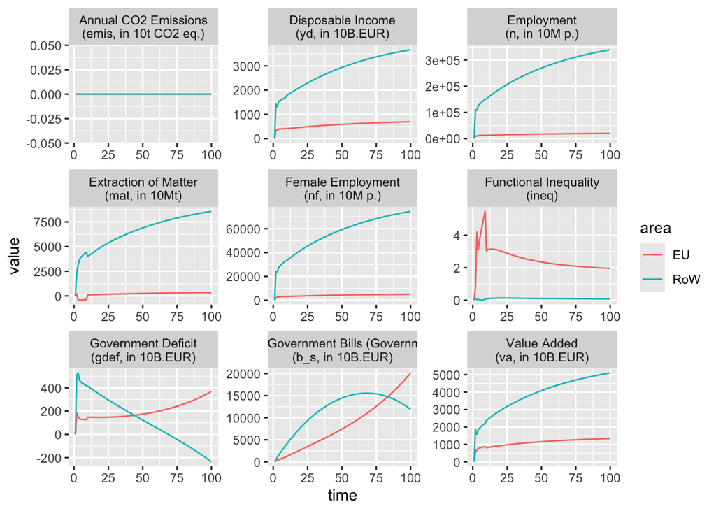

```r
selected <- c('va', 'n', 'nf', 'ineq', 'emis', 'mat', 'gdef', 'b_s', 'yd')

p.selected <- plot.vars(baseline.54, selected)
```

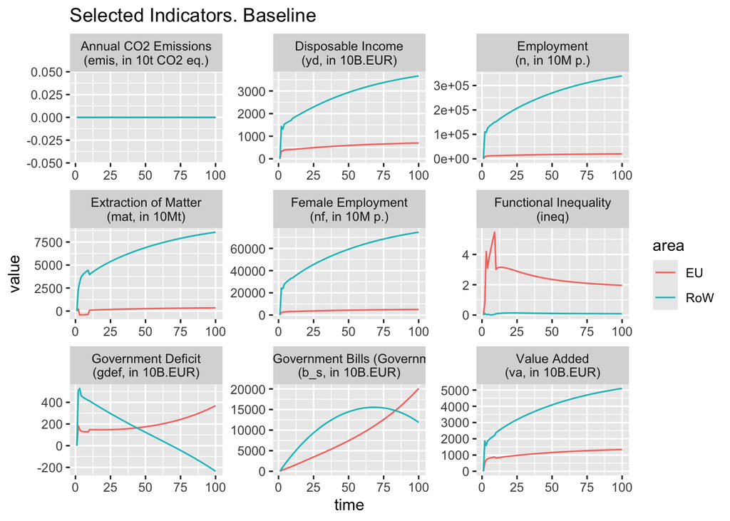

```r
p.selected + ggtitle('Selected Indicators. Baseline')
```

# Shock Example

## Simple Visualization

This is a simple visualization of shock 1.

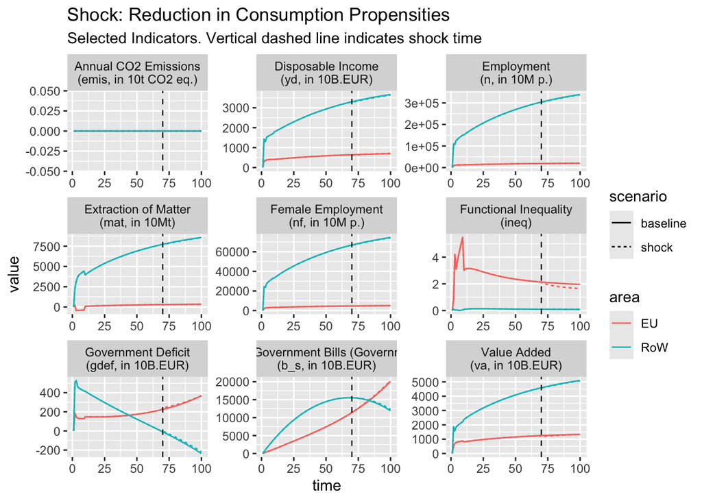

```r
initial$parameters['shock', ] <- 1 # shock 1
# shock.1.54 <- run.new.model(initial, mvp.model)
# saveRDS(shock.1.54, paste0(directory, 'data/shock54.RDS'))

shock.1.54 <- readRDS(paste0(directory, 'data/shock54.RDS'))
shock.title <- paste0('Shock: Reduction in Consumption Propensities')

df <- shock.long.new(baseline.54, shock.1.54)

# Selected Vars to plot
p.selected.vars <- filter(df, variable %in% selected) %>%
    ggplot(aes(x = time, y = value, color = area, linetype = scenario)) + facet_wrap(~ name, scales = 'free') + geom_line() +
    geom_vline(xintercept = initial$parameters['t.shock', ], linetype = 'dashed', linewidth = .4) +
    labs(title = shock.title, subtitle = 'Selected Indicators. Vertical dashed line indicates shock time')

p.selected.vars
```

## Scaled Visualization

This is a scaled visualization of shock 1.

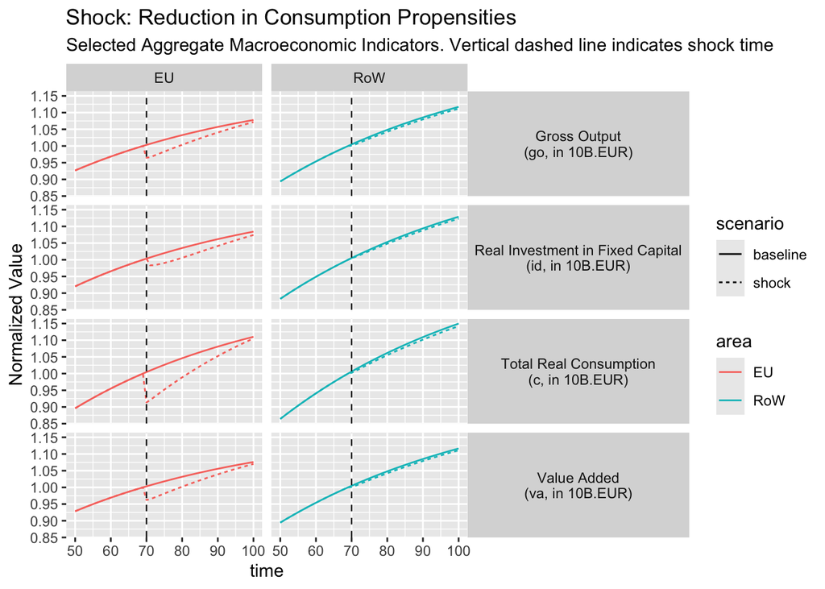

```r
# Variable Selection
macro.vars <- c('c', 'va', 'go','id')
external.vars <- c('cab', 'gdef', 'tb', 'nimp')
social.vars <- c('n', 'nf', 'ineq', 'pa')

# Time Period Selection
t.shock <- initial$parameters['t.shock', ] # shock time period
t0 <- 50 # initial time period for visualization
tf <- initial$parameters['nPeriods', ] # final time period for visualization

# df <- shock.long.new(baseline.54, shock.1.54) # already run above
df <- df %>% filter(time >= t0 & time <= tf)
df$ref.value <- rep(filter(df, time == (t.shock - 1)) %>% select(value), times = tf - t0 + 1) %>% unlist
df$norm.value <- df$value / df$ref.value

# Macro Vars
p.macro <- filter(df, variable %in% macro.vars) %>% ggplot(aes(x = time, y = norm.value, color = area, linetype = scenario)) + ylab('Normalized Value') +
  facet_grid(name ~ area) + geom_line() + theme(strip.text.y.right = element_text(angle = 0)) +
  geom_vline(xintercept = t.shock, linetype = 'dashed', linewidth = .4) +
  labs(title = shock.title, subtitle = 'Selected Aggregate Macroeconomic Indicators. Vertical dashed line indicates shock time') + coord_cartesian(xlim = c(t0, tf))

# Social Vars
p.social <- filter(df, variable %in% social.vars) %>% ggplot(aes(x = time, y = norm.value, color = area, linetype = scenario)) + ylab('Normalized Value') +
  facet_grid(name ~ area) + geom_line() + theme(strip.text.y.right = element_text(angle = 0)) +
  geom_vline(xintercept = t.shock, linetype = 'dashed', linewidth = .4) +
  labs(title = shock.title, subtitle = 'Selected Aggregate Social Indicators. Vertical dashed line indicates shock time') + coord_cartesian(xlim = c(t0, tf))

# External Vars
p.external <- filter(df, variable %in% external.vars) %>% ggplot(aes(x = time, y = value, color = area, linetype = scenario)) + ylab('Value') +
  facet_grid(name ~ area, scales = 'free_y') + geom_line() + theme(strip.text.y.right = element_text(angle = 0)) +
  geom_vline(xintercept = t.shock, linetype = 'dashed', linewidth = .4) +
  labs(title = shock.title, subtitle = 'Balance of Payments and Government Balance Indicators. Vertical dashed line indicates shock time') + coord_cartesian(xlim = c(t0, tf))

# Print Plots
print(p.macro)
```

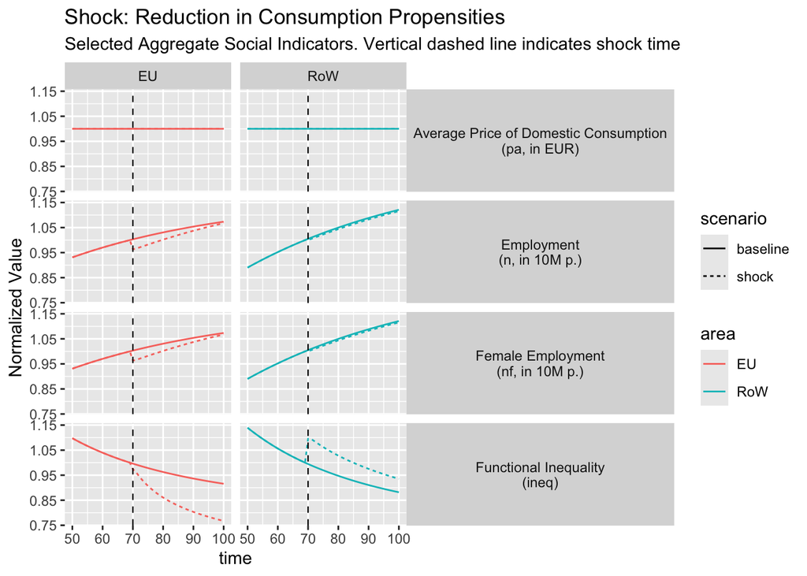

```r
print(p.social)
```

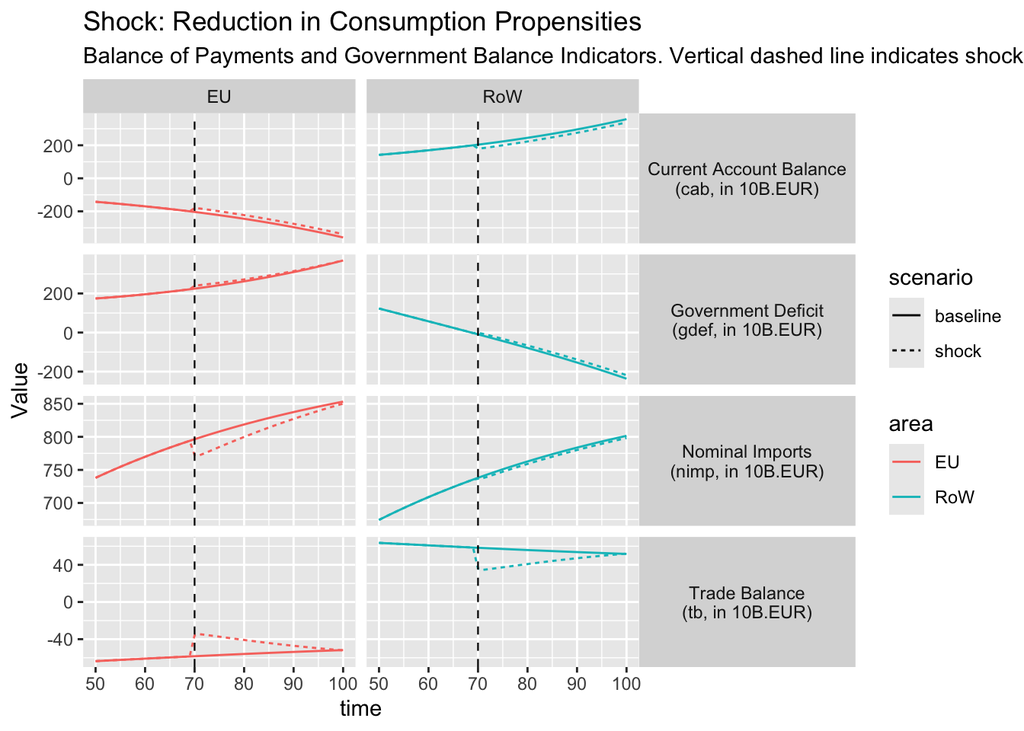

```r
print(p.external)
```

# Calibration

## Load Target Set and Table

Target values are loaded in format long (`target.set`) and wide (`target.table.0`). Units are divided by 10,000 for convenience.

```r
#### LOAD TARGET VALUES ####
target.file <- paste0(directory, 'data/target_values.xlsx')
target.table.0 <- openxlsx :: read.xlsx(target.file, sheet = 'Target', rowNames = TRUE) / 10000
target.set <- data.frame(area = rep(c('Z1', 'Z2'), times = dim(target.table.0)[2]),
                         var.label = rep(c('c', 'id', 'g', 'rex', 'imp', NA, 'M_TOT_int', NA, 'va', NA, 'gdef', NA, NA), each = 2),
                         value = unlist(target.table.0))
target.set$var[!is.na(target.set$var.label)] <- paste0(target.set$area[!is.na(target.set$var.label)], '_', target.set$var[!is.na(target.set$var.label)])
target.set$type <- setNames(variable.table$type, variable.table$label)[target.set$var.label]
target.set$variable <- paste0(setNames(variable.table$name, variable.table$label)[target.set$var.label], '\n(', target.set$var.label, ')')

head(target.set)
```

```
##    area var.label     value   var              type
## C1   Z1         c  626.3179  Z1_c        households
## C2   Z2         c 2370.7060  Z2_c        households
## I1   Z1        id  245.7689 Z1_id        investment
## I2   Z2        id 1135.8401 Z2_id        investment
## G1   Z1         g  239.4593  Z1_g govt.central.bank
## G2   Z2         g  675.3284  Z2_g govt.central.bank
##                                  variable
## C1            Total Real Consumption\n(c)
## C2            Total Real Consumption\n(c)
## I1 Real Investment in Fixed Capital\n(id)
## I2 Real Investment in Fixed Capital\n(id)
## G1               Government Spending\n(g)
## G2               Government Spending\n(g)
```

```r
# target.variables <- colnames(target.table.0)
target.variables <- c('GDEF', 'DEBT.GDP', 'BS')
target.indices <- colnames(target.table.0) %in% target.variables
target.table <- target.table.0[ , target.indices]

target.table.0
```

```
##             C         I        G         X         M    X.int    M.int       FD
## EU   626.3179  245.7689 239.4593 102.77593  66.35708 105.8546 123.1518 1147.965
## ROW 2370.7060 1135.8401 675.3284  66.35708 102.77593 123.1518 105.8546 4145.456
##          GDP       GO GDEF DEBT.GDP  BS
## EU  1130.668 2153.602 0.01      0.8 100
## ROW 4162.753 8424.517 0.01      0.6 100
```

## Select Instrument Variables

We select instrument variables:

```r
instruments <- list(var = c(paste0('Z1_kappa-', 1 : 5), paste0('Z2_kappa-', 6 : 10),
                            'Z1_id0', 'Z2_id0',
                            paste0('Z1_vat-', 1 : 5), paste0('Z2_vat-', 6 : 10),
                           paste0('Z1_tar-', 1 : 5), paste0('Z2_tar-', 6 : 10),
                           'Z1_theta_w', 'Z2_theta_w', 'Z1_theta_c', 'Z2_theta_c',
                           'Z1_mu_b', 'Z2_mu_b', 'Z1_r_star', 'Z2_r_star'),
                    par = c('Z1_bs0', 'Z2_bs0', 'Z1_k0', 'Z2_k0',
                            'Z1_gamma', 'Z2_gamma','Z1_gg0', 'Z2_gg0', 'Z1_delta', 'Z2_delta'))
```

## Random Search Algorithm

```r
std.dev <- .1
results <- baseline.54 # initial run
universe <- list() # universe is a list that saves each run of the model for each of its elements
universe[[1]] <- list(initial = results$initial,
                      instruments = return.instr.vals(results),# instrument values
                      simulation = results$simulation,         # simulation values
                      target = results$values,                 # values of target variables
                      ratio = results$ratios,                  # target/actual ratios (should be 1)
                      fitness = results$fitness)  # fitness value (a sum of the ratios - 1)

# WHILE LOOP
iters <- k <- 1
print('ITERATIONS  SUCCESSFUL.RUNS   CURRENT.FITNESS  RUN.FITNESS   DIFFERENCE')
print(c(iters, k, universe[[k]]$fitness))
while (iters < 20)
{
  # Adjust Parameters and Run Model
  sim <- universe[[k]]$initial
  sim$variables[instruments$var, 't1'] <- rnorm(length(instruments$var), 1, std.dev) * sim$variables[instruments$var, 't1']
  sim$parameters[instruments$par, ] <- rnorm(length(instruments$par), 1, std.dev) * sim$parameters[instruments$par, ]

  # Boundary Conditions so Parameters are Meaningful
  if(sim$parameters['Z1_alpha1', ] > 1) sim$parameters['Z1_alpha1', ] <- .99
  if(sim$parameters['Z1_alpha2', ] > 1) sim$parameters['Z1_alpha2', ] <- .99
  if(sim$parameters['Z1_alpha3', ] > 1) sim$parameters['Z1_alpha3', ] <- .99

  if(sim$parameters['Z2_alpha1', ] > 1) sim$parameters['Z2_alpha1', ] <- .99
  if(sim$parameters['Z2_alpha2', ] > 1) sim$parameters['Z2_alpha2', ] <- .99
  if(sim$parameters['Z2_alpha3', ] > 1) sim$parameters['Z2_alpha3', ] <- .99

  if(sim$parameters['Z1_alpha2', ] > sim$parameters['Z1_alpha1', ]) sim$parameters['Z1_alpha2', ] <- sim$parameters['Z1_alpha1', ]
  if(sim$parameters['Z1_alpha3', ] > sim$parameters['Z1_alpha2', ]) sim$parameters['Z1_alpha3', ] <- sim$parameters['Z1_alpha2', ]

  if(sim$parameters['Z2_alpha2', ] > sim$parameters['Z2_alpha1', ]) sim$parameters['Z2_alpha2', ] <- sim$parameters['Z2_alpha1', ]
  if(sim$parameters['Z2_alpha3', ] > sim$parameters['Z2_alpha2', ]) sim$parameters['Z2_alpha3', ] <- sim$parameters['Z2_alpha2', ]

  if(sum(sim$parameters[paste0('Z1_lambda', 1 : 4, '0'), ]) > 1)
    sim$parameters[paste0('Z1_lambda', 1 : 4, '0'), ] <- sim$parameters[paste0('Z1_lambda', 1 : 4, '0'), ] / sum(sim$parameters[paste0('Z1_lambda', 1 : 4, '0'), ])
  if(sum(sim$parameters[paste0('Z2_lambda', 1 : 4, '0'), ]) > 1)
    sim$parameters[paste0('Z2_lambda', 1 : 4, '0'), ] <- sim$parameters[paste0('Z2_lambda', 1 : 4, '0'), ] / sum(sim$parameters[paste0('Z2_lambda', 1 : 4, '0'), ])

  results <- run.model(sim)

  # If New Fitness is Lower, Save Parameters
  if (universe[[k]]$fitness > results$fitness)
  {
    # if (abs(results$simulation$variables['Z1_gdef', 75]) < 10 & abs(results$simulation$variables['Z2_gdef', 75]) < 10)
    # {
      k <- k + 1
      universe[[k]] <- list(initial = sim,
                            instruments = return.instr.vals(results),
                            simulation = results$simulation,
                            target = results$values,
                            ratio = results$ratios,
                            fitness = results$fitness)
#    }
  }
  print(c(iters <- iters + 1, k, universe[[k]]$fitness, results$fitness, universe[[k]]$fitness - results$fitness))
}
universe[[k]]$ratio
```